# Risk Factor Analysis

## Outcome Variable

**Outcome Variable:** y_rate_haz

## Predictor Variables

**Intervention Variable:** hdlvry

**Adjustment Set:**

- arm
- sex
- W_mage
- meducyrs
- feducyrs
- W_nrooms
- brthmon
- W_parity
- impsan
- delta_W_mage
- delta_meducyrs
- delta_feducyrs
- delta_W_nrooms
- delta_brthmon
- delta_W_parity
- delta_impsan

## Stratifying Variables

The analysis was stratified on these variable(s):

- agecat
- studyid
- country

## Data Summary

| agecat | studyid | country | hdlvry | n_cell | n |
| --- | --- | --- | --- | --- | --- |
| 0-3 months | ki1017093b-PROVIDE | BANGLADESH | 0 | 474 | 634 |
| 0-3 months | ki1017093b-PROVIDE | BANGLADESH | 1 | 160 | 634 |
| 0-3 months | ki1017093c-NIH-Crypto | BANGLADESH | 0 | 557 | 720 |
| 0-3 months | ki1017093c-NIH-Crypto | BANGLADESH | 1 | 163 | 720 |
| 0-3 months | kiGH5241-JiVitA-3 | BANGLADESH | 0 | 33 | 313 |
| 0-3 months | kiGH5241-JiVitA-3 | BANGLADESH | 1 | 280 | 313 |
| 0-3 months | kiGH5241-JiVitA-4 | BANGLADESH | 0 | 369 | 1796 |
| 0-3 months | kiGH5241-JiVitA-4 | BANGLADESH | 1 | 1427 | 1796 |
| 0-3 months | ki1000108-CMC-V-BCS-2002 | INDIA | 0 | 87 | 87 |
| 0-3 months | ki1000108-IRC | INDIA | 0 | 370 | 377 |
| 0-3 months | ki1000108-IRC | INDIA | 1 | 7 | 377 |
| 0-3 months | ki1000304b-SAS-CompFeed | INDIA | 0 | 127 | 976 |
| 0-3 months | ki1000304b-SAS-CompFeed | INDIA | 1 | 849 | 976 |
| 0-3 months | ki1135781-COHORTS | INDIA | 0 | 2863 | 4580 |
| 0-3 months | ki1135781-COHORTS | INDIA | 1 | 1717 | 4580 |
| 0-3 months | ki1000109-EE | PAKISTAN | 0 | 193 | 295 |
| 0-3 months | ki1000109-EE | PAKISTAN | 1 | 102 | 295 |
| 3-6 months | ki1017093b-PROVIDE | BANGLADESH | 0 | 428 | 574 |
| 3-6 months | ki1017093b-PROVIDE | BANGLADESH | 1 | 146 | 574 |
| 3-6 months | ki1017093c-NIH-Crypto | BANGLADESH | 0 | 536 | 695 |
| 3-6 months | ki1017093c-NIH-Crypto | BANGLADESH | 1 | 159 | 695 |
| 3-6 months | kiGH5241-JiVitA-3 | BANGLADESH | 0 | 28 | 275 |
| 3-6 months | kiGH5241-JiVitA-3 | BANGLADESH | 1 | 247 | 275 |
| 3-6 months | kiGH5241-JiVitA-4 | BANGLADESH | 0 | 412 | 1752 |
| 3-6 months | kiGH5241-JiVitA-4 | BANGLADESH | 1 | 1340 | 1752 |
| 3-6 months | ki1000108-CMC-V-BCS-2002 | INDIA | 0 | 298 | 305 |
| 3-6 months | ki1000108-CMC-V-BCS-2002 | INDIA | 1 | 7 | 305 |
| 3-6 months | ki1000108-IRC | INDIA | 0 | 389 | 397 |
| 3-6 months | ki1000108-IRC | INDIA | 1 | 8 | 397 |
| 3-6 months | ki1000304b-SAS-CompFeed | INDIA | 0 | 124 | 919 |
| 3-6 months | ki1000304b-SAS-CompFeed | INDIA | 1 | 795 | 919 |
| 3-6 months | ki1135781-COHORTS | INDIA | 0 | 2754 | 4481 |
| 3-6 months | ki1135781-COHORTS | INDIA | 1 | 1727 | 4481 |
| 3-6 months | ki1113344-GMS-Nepal | NEPAL | 0 | 102 | 438 |
| 3-6 months | ki1113344-GMS-Nepal | NEPAL | 1 | 336 | 438 |
| 3-6 months | ki1000109-EE | PAKISTAN | 0 | 218 | 329 |
| 3-6 months | ki1000109-EE | PAKISTAN | 1 | 111 | 329 |
| 3-6 months | ki1066203-TanzaniaChild2 | TANZANIA, UNITED REPUBLIC OF | 0 | 1549 | 1577 |
| 3-6 months | ki1066203-TanzaniaChild2 | TANZANIA, UNITED REPUBLIC OF | 1 | 28 | 1577 |
| 6-12 months | ki1017093b-PROVIDE | BANGLADESH | 0 | 404 | 545 |
| 6-12 months | ki1017093b-PROVIDE | BANGLADESH | 1 | 141 | 545 |
| 6-12 months | ki1017093c-NIH-Crypto | BANGLADESH | 0 | 523 | 676 |
| 6-12 months | ki1017093c-NIH-Crypto | BANGLADESH | 1 | 153 | 676 |
| 6-12 months | kiGH5241-JiVitA-3 | BANGLADESH | 0 | 29 | 243 |
| 6-12 months | kiGH5241-JiVitA-3 | BANGLADESH | 1 | 214 | 243 |
| 6-12 months | kiGH5241-JiVitA-4 | BANGLADESH | 0 | 750 | 2803 |
| 6-12 months | kiGH5241-JiVitA-4 | BANGLADESH | 1 | 2053 | 2803 |
| 6-12 months | ki1000108-CMC-V-BCS-2002 | INDIA | 0 | 314 | 321 |
| 6-12 months | ki1000108-CMC-V-BCS-2002 | INDIA | 1 | 7 | 321 |
| 6-12 months | ki1000108-IRC | INDIA | 0 | 392 | 400 |
| 6-12 months | ki1000108-IRC | INDIA | 1 | 8 | 400 |
| 6-12 months | ki1000304b-SAS-CompFeed | INDIA | 0 | 131 | 936 |
| 6-12 months | ki1000304b-SAS-CompFeed | INDIA | 1 | 805 | 936 |
| 6-12 months | ki1000304b-SAS-FoodSuppl | INDIA | 0 | 67 | 332 |
| 6-12 months | ki1000304b-SAS-FoodSuppl | INDIA | 1 | 265 | 332 |
| 6-12 months | ki1135781-COHORTS | INDIA | 0 | 2239 | 3598 |
| 6-12 months | ki1135781-COHORTS | INDIA | 1 | 1359 | 3598 |
| 6-12 months | ki1113344-GMS-Nepal | NEPAL | 0 | 105 | 446 |
| 6-12 months | ki1113344-GMS-Nepal | NEPAL | 1 | 341 | 446 |
| 6-12 months | ki1000109-EE | PAKISTAN | 0 | 4 | 4 |
| 6-12 months | ki1066203-TanzaniaChild2 | TANZANIA, UNITED REPUBLIC OF | 0 | 1015 | 1025 |
| 6-12 months | ki1066203-TanzaniaChild2 | TANZANIA, UNITED REPUBLIC OF | 1 | 10 | 1025 |
| 12-24 months | ki1017093b-PROVIDE | BANGLADESH | 0 | 340 | 458 |
| 12-24 months | ki1017093b-PROVIDE | BANGLADESH | 1 | 118 | 458 |
| 12-24 months | ki1017093c-NIH-Crypto | BANGLADESH | 0 | 379 | 495 |
| 12-24 months | ki1017093c-NIH-Crypto | BANGLADESH | 1 | 116 | 495 |
| 12-24 months | kiGH5241-JiVitA-3 | BANGLADESH | 0 | 24 | 191 |
| 12-24 months | kiGH5241-JiVitA-3 | BANGLADESH | 1 | 167 | 191 |
| 12-24 months | kiGH5241-JiVitA-4 | BANGLADESH | 0 | 805 | 3107 |
| 12-24 months | kiGH5241-JiVitA-4 | BANGLADESH | 1 | 2302 | 3107 |
| 12-24 months | ki1000108-CMC-V-BCS-2002 | INDIA | 0 | 315 | 322 |
| 12-24 months | ki1000108-CMC-V-BCS-2002 | INDIA | 1 | 7 | 322 |
| 12-24 months | ki1000108-IRC | INDIA | 0 | 388 | 396 |
| 12-24 months | ki1000108-IRC | INDIA | 1 | 8 | 396 |
| 12-24 months | ki1135781-COHORTS | INDIA | 0 | 1876 | 2999 |
| 12-24 months | ki1135781-COHORTS | INDIA | 1 | 1123 | 2999 |
| 12-24 months | ki1113344-GMS-Nepal | NEPAL | 0 | 86 | 341 |
| 12-24 months | ki1113344-GMS-Nepal | NEPAL | 1 | 255 | 341 |
| 12-24 months | ki1066203-TanzaniaChild2 | TANZANIA, UNITED REPUBLIC OF | 0 | 2 | 2 |

The following strata were considered:

- agecat: 0-3 months, studyid: ki1000108-CMC-V-BCS-2002, country: INDIA
- agecat: 0-3 months, studyid: ki1000108-IRC, country: INDIA
- agecat: 0-3 months, studyid: ki1000109-EE, country: PAKISTAN
- agecat: 0-3 months, studyid: ki1000304b-SAS-CompFeed, country: INDIA
- agecat: 0-3 months, studyid: ki1017093b-PROVIDE, country: BANGLADESH
- agecat: 0-3 months, studyid: ki1017093c-NIH-Crypto, country: BANGLADESH
- agecat: 0-3 months, studyid: ki1135781-COHORTS, country: INDIA
- agecat: 0-3 months, studyid: kiGH5241-JiVitA-3, country: BANGLADESH
- agecat: 0-3 months, studyid: kiGH5241-JiVitA-4, country: BANGLADESH
- agecat: 12-24 months, studyid: ki1000108-CMC-V-BCS-2002, country: INDIA
- agecat: 12-24 months, studyid: ki1000108-IRC, country: INDIA
- agecat: 12-24 months, studyid: ki1017093b-PROVIDE, country: BANGLADESH
- agecat: 12-24 months, studyid: ki1017093c-NIH-Crypto, country: BANGLADESH
- agecat: 12-24 months, studyid: ki1066203-TanzaniaChild2, country: TANZANIA, UNITED REPUBLIC OF
- agecat: 12-24 months, studyid: ki1113344-GMS-Nepal, country: NEPAL
- agecat: 12-24 months, studyid: ki1135781-COHORTS, country: INDIA
- agecat: 12-24 months, studyid: kiGH5241-JiVitA-3, country: BANGLADESH
- agecat: 12-24 months, studyid: kiGH5241-JiVitA-4, country: BANGLADESH
- agecat: 3-6 months, studyid: ki1000108-CMC-V-BCS-2002, country: INDIA
- agecat: 3-6 months, studyid: ki1000108-IRC, country: INDIA
- agecat: 3-6 months, studyid: ki1000109-EE, country: PAKISTAN
- agecat: 3-6 months, studyid: ki1000304b-SAS-CompFeed, country: INDIA
- agecat: 3-6 months, studyid: ki1017093b-PROVIDE, country: BANGLADESH
- agecat: 3-6 months, studyid: ki1017093c-NIH-Crypto, country: BANGLADESH
- agecat: 3-6 months, studyid: ki1066203-TanzaniaChild2, country: TANZANIA, UNITED REPUBLIC OF
- agecat: 3-6 months, studyid: ki1113344-GMS-Nepal, country: NEPAL
- agecat: 3-6 months, studyid: ki1135781-COHORTS, country: INDIA
- agecat: 3-6 months, studyid: kiGH5241-JiVitA-3, country: BANGLADESH
- agecat: 3-6 months, studyid: kiGH5241-JiVitA-4, country: BANGLADESH
- agecat: 6-12 months, studyid: ki1000108-CMC-V-BCS-2002, country: INDIA
- agecat: 6-12 months, studyid: ki1000108-IRC, country: INDIA
- agecat: 6-12 months, studyid: ki1000109-EE, country: PAKISTAN
- agecat: 6-12 months, studyid: ki1000304b-SAS-CompFeed, country: INDIA
- agecat: 6-12 months, studyid: ki1000304b-SAS-FoodSuppl, country: INDIA
- agecat: 6-12 months, studyid: ki1017093b-PROVIDE, country: BANGLADESH
- agecat: 6-12 months, studyid: ki1017093c-NIH-Crypto, country: BANGLADESH
- agecat: 6-12 months, studyid: ki1066203-TanzaniaChild2, country: TANZANIA, UNITED REPUBLIC OF
- agecat: 6-12 months, studyid: ki1113344-GMS-Nepal, country: NEPAL
- agecat: 6-12 months, studyid: ki1135781-COHORTS, country: INDIA
- agecat: 6-12 months, studyid: kiGH5241-JiVitA-3, country: BANGLADESH
- agecat: 6-12 months, studyid: kiGH5241-JiVitA-4, country: BANGLADESH

### Dropped Strata

Some strata were dropped due to rare outcomes:

- agecat: 6-12 months, studyid: ki1000109-EE, country: PAKISTAN
- agecat: 12-24 months, studyid: ki1066203-TanzaniaChild2, country: TANZANIA, UNITED REPUBLIC OF

## Methods Detail

We’re interested in the causal parameters $E[Y_a]$ for all values of $a \in \mathcal{A}$. These parameters represent the mean outcome if, possibly contrary to fact, we intervened to set all units to have $A=a$. Under the randomization and positivity assumptions, these are identified by the statistical parameters $\psi_a=E_W[E_{Y|A,W}(Y|A=a,W)]$. In addition, we’re interested in the mean of $Y$, $E[Y]$ under no intervention (the observed mean). We will estimate these parameters by using SuperLearner to fit the relevant likelihood factors – $E_{Y|A,W}(Y|A=a,W)$ and $p(A=a|W)$, and then updating our likelihood fit using a joint TMLE.

For unadjusted analyses ($W=\{\}$), initial likelihoods were estimated using Lrnr_glm to estimate the simple $E(Y|A)$ and Lrnr_mean to estimate $p(A)$. For adjusted analyses, a small library containing Lrnr_glmnet, Lrnr_xgboost, and Lrnr_mean was used.

[output not shown]

[output cut: 49 more lines]

[output not shown]

# Results Detail

## Results Plots

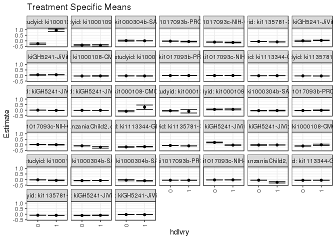

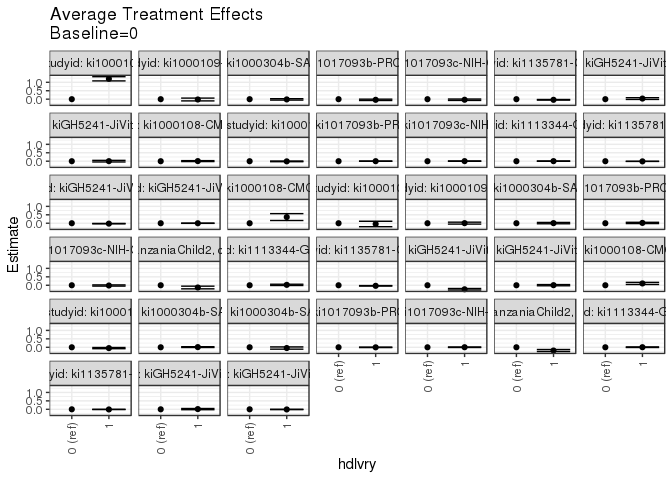

## Results Table

### Parameter: TSM

| agecat | studyid | country | intervention_level | baseline_level | estimate | ci_lower | ci_upper |
| --- | --- | --- | --- | --- | --- | --- | --- |
| 0-3 months | ki1000108-IRC | INDIA | 0 | NA | -0.2573121 | -0.3135633 | -0.2010609 |
| 0-3 months | ki1000108-IRC | INDIA | 1 | NA | 0.9507022 | 0.8365773 | 1.0648270 |
| 0-3 months | ki1000109-EE | PAKISTAN | 0 | NA | -0.3869236 | -0.4440888 | -0.3297585 |
| 0-3 months | ki1000109-EE | PAKISTAN | 1 | NA | -0.4053109 | -0.4651267 | -0.3454951 |
| 0-3 months | ki1000304b-SAS-CompFeed | INDIA | 0 | NA | 0.0179486 | -0.0254773 | 0.0613744 |
| 0-3 months | ki1000304b-SAS-CompFeed | INDIA | 1 | NA | 0.0038599 | -0.0072595 | 0.0149792 |
| 0-3 months | ki1017093b-PROVIDE | BANGLADESH | 0 | NA | -0.0300346 | -0.0511620 | -0.0089071 |
| 0-3 months | ki1017093b-PROVIDE | BANGLADESH | 1 | NA | -0.0676716 | -0.0992791 | -0.0360640 |
| 0-3 months | ki1017093c-NIH-Crypto | BANGLADESH | 0 | NA | -0.1145094 | -0.1352139 | -0.0938049 |
| 0-3 months | ki1017093c-NIH-Crypto | BANGLADESH | 1 | NA | -0.1477871 | -0.1820042 | -0.1135700 |
| 0-3 months | ki1135781-COHORTS | INDIA | 0 | NA | -0.0592727 | -0.0698658 | -0.0486795 |
| 0-3 months | ki1135781-COHORTS | INDIA | 1 | NA | -0.0967053 | -0.1093169 | -0.0840937 |
| 0-3 months | kiGH5241-JiVitA-3 | BANGLADESH | 0 | NA | 0.0024957 | -0.0492327 | 0.0542241 |
| 0-3 months | kiGH5241-JiVitA-3 | BANGLADESH | 1 | NA | 0.0387975 | 0.0108476 | 0.0667474 |
| 0-3 months | kiGH5241-JiVitA-4 | BANGLADESH | 0 | NA | 0.0654700 | 0.0223302 | 0.1086098 |
| 0-3 months | kiGH5241-JiVitA-4 | BANGLADESH | 1 | NA | 0.0683131 | 0.0524244 | 0.0842017 |
| 3-6 months | ki1000108-CMC-V-BCS-2002 | INDIA | 0 | NA | -0.0969975 | -0.1452883 | -0.0487067 |
| 3-6 months | ki1000108-CMC-V-BCS-2002 | INDIA | 1 | NA | 0.2680102 | 0.0700520 | 0.4659684 |
| 3-6 months | ki1000108-IRC | INDIA | 0 | NA | -0.0509880 | -0.0814920 | -0.0204840 |
| 3-6 months | ki1000108-IRC | INDIA | 1 | NA | -0.0958580 | -0.2540005 | 0.0622844 |
| 3-6 months | ki1000109-EE | PAKISTAN | 0 | NA | 0.0689209 | 0.0337409 | 0.1041009 |
| 3-6 months | ki1000109-EE | PAKISTAN | 1 | NA | 0.0744003 | 0.0283881 | 0.1204124 |
| 3-6 months | ki1000304b-SAS-CompFeed | INDIA | 0 | NA | -0.0413589 | -0.0632006 | -0.0195173 |
| 3-6 months | ki1000304b-SAS-CompFeed | INDIA | 1 | NA | -0.0346496 | -0.0659788 | -0.0033205 |
| 3-6 months | ki1017093b-PROVIDE | BANGLADESH | 0 | NA | -0.0317763 | -0.0508842 | -0.0126684 |
| 3-6 months | ki1017093b-PROVIDE | BANGLADESH | 1 | NA | -0.0123941 | -0.0436282 | 0.0188400 |
| 3-6 months | ki1017093c-NIH-Crypto | BANGLADESH | 0 | NA | 0.0303449 | 0.0110589 | 0.0496309 |
| 3-6 months | ki1017093c-NIH-Crypto | BANGLADESH | 1 | NA | 0.0152517 | -0.0141628 | 0.0446663 |
| 3-6 months | ki1066203-TanzaniaChild2 | TANZANIA, UNITED REPUBLIC OF | 0 | NA | -0.0860014 | -0.1031692 | -0.0688336 |
| 3-6 months | ki1066203-TanzaniaChild2 | TANZANIA, UNITED REPUBLIC OF | 1 | NA | -0.2186519 | -0.2949367 | -0.1423672 |
| 3-6 months | ki1113344-GMS-Nepal | NEPAL | 0 | NA | -0.1880771 | -0.2185068 | -0.1576474 |
| 3-6 months | ki1113344-GMS-Nepal | NEPAL | 1 | NA | -0.1635945 | -0.1852295 | -0.1419596 |
| 3-6 months | ki1135781-COHORTS | INDIA | 0 | NA | -0.0574032 | -0.0658894 | -0.0489171 |
| 3-6 months | ki1135781-COHORTS | INDIA | 1 | NA | -0.0910467 | -0.1011012 | -0.0809921 |
| 3-6 months | kiGH5241-JiVitA-3 | BANGLADESH | 0 | NA | 0.2169567 | 0.1808866 | 0.2530268 |
| 3-6 months | kiGH5241-JiVitA-3 | BANGLADESH | 1 | NA | -0.0223014 | -0.0507612 | 0.0061584 |
| 3-6 months | kiGH5241-JiVitA-4 | BANGLADESH | 0 | NA | -0.0147423 | -0.0473518 | 0.0178671 |
| 3-6 months | kiGH5241-JiVitA-4 | BANGLADESH | 1 | NA | -0.0094299 | -0.0240647 | 0.0052049 |
| 6-12 months | ki1000108-CMC-V-BCS-2002 | INDIA | 0 | NA | -0.1005054 | -0.1215030 | -0.0795078 |
| 6-12 months | ki1000108-CMC-V-BCS-2002 | INDIA | 1 | NA | 0.0065186 | -0.0515395 | 0.0645766 |
| 6-12 months | ki1000108-IRC | INDIA | 0 | NA | -0.0258372 | -0.0388730 | -0.0128014 |
| 6-12 months | ki1000108-IRC | INDIA | 1 | NA | -0.0750090 | -0.1071872 | -0.0428308 |
| 6-12 months | ki1000304b-SAS-CompFeed | INDIA | 0 | NA | -0.0964600 | -0.1153931 | -0.0775270 |
| 6-12 months | ki1000304b-SAS-CompFeed | INDIA | 1 | NA | -0.0861829 | -0.0934891 | -0.0788766 |
| 6-12 months | ki1000304b-SAS-FoodSuppl | INDIA | 0 | NA | -0.0608924 | -0.1184910 | -0.0032937 |
| 6-12 months | ki1000304b-SAS-FoodSuppl | INDIA | 1 | NA | -0.1057454 | -0.1394969 | -0.0719940 |
| 6-12 months | ki1017093b-PROVIDE | BANGLADESH | 0 | NA | -0.0616946 | -0.0698192 | -0.0535700 |
| 6-12 months | ki1017093b-PROVIDE | BANGLADESH | 1 | NA | -0.0643027 | -0.0766904 | -0.0519149 |
| 6-12 months | ki1017093c-NIH-Crypto | BANGLADESH | 0 | NA | -0.0323660 | -0.0407273 | -0.0240047 |
| 6-12 months | ki1017093c-NIH-Crypto | BANGLADESH | 1 | NA | -0.0286411 | -0.0419436 | -0.0153385 |
| 6-12 months | ki1066203-TanzaniaChild2 | TANZANIA, UNITED REPUBLIC OF | 0 | NA | -0.0604009 | -0.0697922 | -0.0510097 |
| 6-12 months | ki1066203-TanzaniaChild2 | TANZANIA, UNITED REPUBLIC OF | 1 | NA | -0.2529788 | -0.3116655 | -0.1942921 |
| 6-12 months | ki1113344-GMS-Nepal | NEPAL | 0 | NA | -0.0681539 | -0.0827750 | -0.0535328 |
| 6-12 months | ki1113344-GMS-Nepal | NEPAL | 1 | NA | -0.0636633 | -0.0736904 | -0.0536362 |
| 6-12 months | ki1135781-COHORTS | INDIA | 0 | NA | -0.0919553 | -0.0971311 | -0.0867795 |
| 6-12 months | ki1135781-COHORTS | INDIA | 1 | NA | -0.1001029 | -0.1063655 | -0.0938403 |
| 6-12 months | kiGH5241-JiVitA-3 | BANGLADESH | 0 | NA | -0.1117420 | -0.1349678 | -0.0885162 |
| 6-12 months | kiGH5241-JiVitA-3 | BANGLADESH | 1 | NA | -0.0982822 | -0.1198227 | -0.0767418 |
| 6-12 months | kiGH5241-JiVitA-4 | BANGLADESH | 0 | NA | -0.0308397 | -0.0387677 | -0.0229117 |
| 6-12 months | kiGH5241-JiVitA-4 | BANGLADESH | 1 | NA | -0.0393588 | -0.0445731 | -0.0341446 |
| 12-24 months | ki1000108-CMC-V-BCS-2002 | INDIA | 0 | NA | -0.0450468 | -0.0551704 | -0.0349233 |
| 12-24 months | ki1000108-CMC-V-BCS-2002 | INDIA | 1 | NA | -0.0381690 | -0.0639426 | -0.0123955 |
| 12-24 months | ki1000108-IRC | INDIA | 0 | NA | -0.0315680 | -0.0387454 | -0.0243906 |
| 12-24 months | ki1000108-IRC | INDIA | 1 | NA | -0.0403240 | -0.0582264 | -0.0224215 |
| 12-24 months | ki1017093b-PROVIDE | BANGLADESH | 0 | NA | -0.0086385 | -0.0129989 | -0.0042781 |
| 12-24 months | ki1017093b-PROVIDE | BANGLADESH | 1 | NA | -0.0067354 | -0.0129797 | -0.0004912 |
| 12-24 months | ki1017093c-NIH-Crypto | BANGLADESH | 0 | NA | -0.0063967 | -0.0109836 | -0.0018097 |
| 12-24 months | ki1017093c-NIH-Crypto | BANGLADESH | 1 | NA | -0.0016044 | -0.0084114 | 0.0052027 |
| 12-24 months | ki1113344-GMS-Nepal | NEPAL | 0 | NA | -0.0208919 | -0.0284387 | -0.0133451 |
| 12-24 months | ki1113344-GMS-Nepal | NEPAL | 1 | NA | -0.0163381 | -0.0226057 | -0.0100705 |
| 12-24 months | ki1135781-COHORTS | INDIA | 0 | NA | -0.0329439 | -0.0353251 | -0.0305626 |
| 12-24 months | ki1135781-COHORTS | INDIA | 1 | NA | -0.0424308 | -0.0454482 | -0.0394135 |
| 12-24 months | kiGH5241-JiVitA-3 | BANGLADESH | 0 | NA | 0.0034716 | -0.0053281 | 0.0122713 |
| 12-24 months | kiGH5241-JiVitA-3 | BANGLADESH | 1 | NA | -0.0197191 | -0.0293405 | -0.0100977 |
| 12-24 months | kiGH5241-JiVitA-4 | BANGLADESH | 0 | NA | -0.0133084 | -0.0172017 | -0.0094152 |
| 12-24 months | kiGH5241-JiVitA-4 | BANGLADESH | 1 | NA | -0.0143700 | -0.0166845 | -0.0120555 |

### Parameter: E(Y)

| agecat | studyid | country | intervention_level | baseline_level | estimate | ci_lower | ci_upper |
| --- | --- | --- | --- | --- | --- | --- | --- |
| 0-3 months | ki1000108-IRC | INDIA | NA | NA | -0.2594964 | -0.3154509 | -0.2035418 |
| 0-3 months | ki1000109-EE | PAKISTAN | NA | NA | -0.3932813 | -0.4361258 | -0.3504368 |
| 0-3 months | ki1000304b-SAS-CompFeed | INDIA | NA | NA | 0.0087093 | -0.0074467 | 0.0248652 |
| 0-3 months | ki1017093b-PROVIDE | BANGLADESH | NA | NA | -0.0413143 | -0.0594662 | -0.0231624 |
| 0-3 months | ki1017093c-NIH-Crypto | BANGLADESH | NA | NA | -0.1220821 | -0.1402761 | -0.1038881 |
| 0-3 months | ki1135781-COHORTS | INDIA | NA | NA | -0.0699385 | -0.0782973 | -0.0615796 |
| 0-3 months | kiGH5241-JiVitA-3 | BANGLADESH | NA | NA | 0.0349097 | 0.0045006 | 0.0653188 |
| 0-3 months | kiGH5241-JiVitA-4 | BANGLADESH | NA | NA | 0.0670726 | 0.0519630 | 0.0821823 |
| 3-6 months | ki1000108-CMC-V-BCS-2002 | INDIA | NA | NA | -0.0954743 | -0.1432951 | -0.0476535 |
| 3-6 months | ki1000108-IRC | INDIA | NA | NA | -0.0518918 | -0.0819849 | -0.0217987 |
| 3-6 months | ki1000109-EE | PAKISTAN | NA | NA | 0.0708740 | 0.0425313 | 0.0992167 |
| 3-6 months | ki1000304b-SAS-CompFeed | INDIA | NA | NA | -0.0318535 | -0.0595705 | -0.0041366 |
| 3-6 months | ki1017093b-PROVIDE | BANGLADESH | NA | NA | -0.0272428 | -0.0436954 | -0.0107902 |
| 3-6 months | ki1017093c-NIH-Crypto | BANGLADESH | NA | NA | 0.0267740 | 0.0099602 | 0.0435879 |
| 3-6 months | ki1066203-TanzaniaChild2 | TANZANIA, UNITED REPUBLIC OF | NA | NA | -0.0872216 | -0.1042720 | -0.0701712 |
| 3-6 months | ki1113344-GMS-Nepal | NEPAL | NA | NA | -0.1634027 | -0.1828407 | -0.1439647 |
| 3-6 months | ki1135781-COHORTS | INDIA | NA | NA | -0.0628577 | -0.0694923 | -0.0562230 |
| 3-6 months | kiGH5241-JiVitA-3 | BANGLADESH | NA | NA | -0.0289883 | -0.0560864 | -0.0018901 |
| 3-6 months | kiGH5241-JiVitA-4 | BANGLADESH | NA | NA | -0.0090395 | -0.0231928 | 0.0051138 |
| 6-12 months | ki1000108-CMC-V-BCS-2002 | INDIA | NA | NA | -0.0991370 | -0.1197790 | -0.0784950 |
| 6-12 months | ki1000108-IRC | INDIA | NA | NA | -0.0260151 | -0.0389122 | -0.0131180 |
| 6-12 months | ki1000304b-SAS-CompFeed | INDIA | NA | NA | -0.0862781 | -0.0919075 | -0.0806486 |
| 6-12 months | ki1000304b-SAS-FoodSuppl | INDIA | NA | NA | -0.1080113 | -0.1390238 | -0.0769988 |
| 6-12 months | ki1017093b-PROVIDE | BANGLADESH | NA | NA | -0.0626151 | -0.0695574 | -0.0556729 |
| 6-12 months | ki1017093c-NIH-Crypto | BANGLADESH | NA | NA | -0.0315658 | -0.0388594 | -0.0242722 |
| 6-12 months | ki1066203-TanzaniaChild2 | TANZANIA, UNITED REPUBLIC OF | NA | NA | -0.0608711 | -0.0702662 | -0.0514759 |
| 6-12 months | ki1113344-GMS-Nepal | NEPAL | NA | NA | -0.0622100 | -0.0707695 | -0.0536506 |
| 6-12 months | ki1135781-COHORTS | INDIA | NA | NA | -0.0962096 | -0.1003863 | -0.0920329 |
| 6-12 months | kiGH5241-JiVitA-3 | BANGLADESH | NA | NA | -0.0968253 | -0.1152285 | -0.0784220 |
| 6-12 months | kiGH5241-JiVitA-4 | BANGLADESH | NA | NA | -0.0371814 | -0.0417180 | -0.0326448 |
| 12-24 months | ki1000108-CMC-V-BCS-2002 | INDIA | NA | NA | -0.0462563 | -0.0562940 | -0.0362186 |
| 12-24 months | ki1000108-IRC | INDIA | NA | NA | -0.0317687 | -0.0388357 | -0.0247017 |
| 12-24 months | ki1017093b-PROVIDE | BANGLADESH | NA | NA | -0.0081718 | -0.0120131 | -0.0043304 |
| 12-24 months | ki1017093c-NIH-Crypto | BANGLADESH | NA | NA | -0.0057326 | -0.0097260 | -0.0017391 |
| 12-24 months | ki1113344-GMS-Nepal | NEPAL | NA | NA | -0.0151200 | -0.0203629 | -0.0098772 |
| 12-24 months | ki1135781-COHORTS | INDIA | NA | NA | -0.0364496 | -0.0384372 | -0.0344620 |
| 12-24 months | kiGH5241-JiVitA-3 | BANGLADESH | NA | NA | -0.0205537 | -0.0303869 | -0.0107206 |
| 12-24 months | kiGH5241-JiVitA-4 | BANGLADESH | NA | NA | -0.0142875 | -0.0163733 | -0.0122017 |

### Parameter: ATE

| agecat | studyid | country | intervention_level | baseline_level | estimate | ci_lower | ci_upper |
| --- | --- | --- | --- | --- | --- | --- | --- |
| 0-3 months | ki1000108-IRC | INDIA | 0 | 0 | 0.0000000 | 0.0000000 | 0.0000000 |
| 0-3 months | ki1000108-IRC | INDIA | 1 | 0 | 1.2080143 | 1.0823716 | 1.3336570 |
| 0-3 months | ki1000109-EE | PAKISTAN | 0 | 0 | 0.0000000 | 0.0000000 | 0.0000000 |
| 0-3 months | ki1000109-EE | PAKISTAN | 1 | 0 | -0.0183873 | -0.1009060 | 0.0641314 |
| 0-3 months | ki1000304b-SAS-CompFeed | INDIA | 0 | 0 | 0.0000000 | 0.0000000 | 0.0000000 |
| 0-3 months | ki1000304b-SAS-CompFeed | INDIA | 1 | 0 | -0.0140887 | -0.0554578 | 0.0272804 |
| 0-3 months | ki1017093b-PROVIDE | BANGLADESH | 0 | 0 | 0.0000000 | 0.0000000 | 0.0000000 |
| 0-3 months | ki1017093b-PROVIDE | BANGLADESH | 1 | 0 | -0.0376370 | -0.0755455 | 0.0002715 |
| 0-3 months | ki1017093c-NIH-Crypto | BANGLADESH | 0 | 0 | 0.0000000 | 0.0000000 | 0.0000000 |
| 0-3 months | ki1017093c-NIH-Crypto | BANGLADESH | 1 | 0 | -0.0332777 | -0.0731046 | 0.0065493 |
| 0-3 months | ki1135781-COHORTS | INDIA | 0 | 0 | 0.0000000 | 0.0000000 | 0.0000000 |
| 0-3 months | ki1135781-COHORTS | INDIA | 1 | 0 | -0.0374327 | -0.0537786 | -0.0210868 |
| 0-3 months | kiGH5241-JiVitA-3 | BANGLADESH | 0 | 0 | 0.0000000 | 0.0000000 | 0.0000000 |
| 0-3 months | kiGH5241-JiVitA-3 | BANGLADESH | 1 | 0 | 0.0363018 | -0.0151631 | 0.0877667 |
| 0-3 months | kiGH5241-JiVitA-4 | BANGLADESH | 0 | 0 | 0.0000000 | 0.0000000 | 0.0000000 |
| 0-3 months | kiGH5241-JiVitA-4 | BANGLADESH | 1 | 0 | 0.0028431 | -0.0436407 | 0.0493268 |
| 3-6 months | ki1000108-CMC-V-BCS-2002 | INDIA | 0 | 0 | 0.0000000 | 0.0000000 | 0.0000000 |
| 3-6 months | ki1000108-CMC-V-BCS-2002 | INDIA | 1 | 0 | 0.3650077 | 0.1612741 | 0.5687413 |
| 3-6 months | ki1000108-IRC | INDIA | 0 | 0 | 0.0000000 | 0.0000000 | 0.0000000 |
| 3-6 months | ki1000108-IRC | INDIA | 1 | 0 | -0.0448700 | -0.2056768 | 0.1159368 |
| 3-6 months | ki1000109-EE | PAKISTAN | 0 | 0 | 0.0000000 | 0.0000000 | 0.0000000 |
| 3-6 months | ki1000109-EE | PAKISTAN | 1 | 0 | 0.0054794 | -0.0520703 | 0.0630290 |
| 3-6 months | ki1000304b-SAS-CompFeed | INDIA | 0 | 0 | 0.0000000 | 0.0000000 | 0.0000000 |
| 3-6 months | ki1000304b-SAS-CompFeed | INDIA | 1 | 0 | 0.0067093 | -0.0315873 | 0.0450059 |
| 3-6 months | ki1017093b-PROVIDE | BANGLADESH | 0 | 0 | 0.0000000 | 0.0000000 | 0.0000000 |
| 3-6 months | ki1017093b-PROVIDE | BANGLADESH | 1 | 0 | 0.0193822 | -0.0171891 | 0.0559535 |
| 3-6 months | ki1017093c-NIH-Crypto | BANGLADESH | 0 | 0 | 0.0000000 | 0.0000000 | 0.0000000 |
| 3-6 months | ki1017093c-NIH-Crypto | BANGLADESH | 1 | 0 | -0.0150932 | -0.0497208 | 0.0195344 |
| 3-6 months | ki1066203-TanzaniaChild2 | TANZANIA, UNITED REPUBLIC OF | 0 | 0 | 0.0000000 | 0.0000000 | 0.0000000 |
| 3-6 months | ki1066203-TanzaniaChild2 | TANZANIA, UNITED REPUBLIC OF | 1 | 0 | -0.1326505 | -0.2106490 | -0.0546520 |
| 3-6 months | ki1113344-GMS-Nepal | NEPAL | 0 | 0 | 0.0000000 | 0.0000000 | 0.0000000 |
| 3-6 months | ki1113344-GMS-Nepal | NEPAL | 1 | 0 | 0.0244826 | -0.0119262 | 0.0608913 |
| 3-6 months | ki1135781-COHORTS | INDIA | 0 | 0 | 0.0000000 | 0.0000000 | 0.0000000 |
| 3-6 months | ki1135781-COHORTS | INDIA | 1 | 0 | -0.0336434 | -0.0467975 | -0.0204893 |
| 3-6 months | kiGH5241-JiVitA-3 | BANGLADESH | 0 | 0 | 0.0000000 | 0.0000000 | 0.0000000 |
| 3-6 months | kiGH5241-JiVitA-3 | BANGLADESH | 1 | 0 | -0.2392581 | -0.2839716 | -0.1945446 |
| 3-6 months | kiGH5241-JiVitA-4 | BANGLADESH | 0 | 0 | 0.0000000 | 0.0000000 | 0.0000000 |
| 3-6 months | kiGH5241-JiVitA-4 | BANGLADESH | 1 | 0 | 0.0053124 | -0.0298413 | 0.0404661 |
| 6-12 months | ki1000108-CMC-V-BCS-2002 | INDIA | 0 | 0 | 0.0000000 | 0.0000000 | 0.0000000 |
| 6-12 months | ki1000108-CMC-V-BCS-2002 | INDIA | 1 | 0 | 0.1070240 | 0.0453147 | 0.1687332 |
| 6-12 months | ki1000108-IRC | INDIA | 0 | 0 | 0.0000000 | 0.0000000 | 0.0000000 |
| 6-12 months | ki1000108-IRC | INDIA | 1 | 0 | -0.0491718 | -0.0834794 | -0.0148643 |
| 6-12 months | ki1000304b-SAS-CompFeed | INDIA | 0 | 0 | 0.0000000 | 0.0000000 | 0.0000000 |
| 6-12 months | ki1000304b-SAS-CompFeed | INDIA | 1 | 0 | 0.0102772 | -0.0134805 | 0.0340348 |
| 6-12 months | ki1000304b-SAS-FoodSuppl | INDIA | 0 | 0 | 0.0000000 | 0.0000000 | 0.0000000 |
| 6-12 months | ki1000304b-SAS-FoodSuppl | INDIA | 1 | 0 | -0.0448531 | -0.1108221 | 0.0211159 |
| 6-12 months | ki1017093b-PROVIDE | BANGLADESH | 0 | 0 | 0.0000000 | 0.0000000 | 0.0000000 |
| 6-12 months | ki1017093b-PROVIDE | BANGLADESH | 1 | 0 | -0.0026081 | -0.0172735 | 0.0120574 |
| 6-12 months | ki1017093c-NIH-Crypto | BANGLADESH | 0 | 0 | 0.0000000 | 0.0000000 | 0.0000000 |
| 6-12 months | ki1017093c-NIH-Crypto | BANGLADESH | 1 | 0 | 0.0037249 | -0.0118509 | 0.0193007 |
| 6-12 months | ki1066203-TanzaniaChild2 | TANZANIA, UNITED REPUBLIC OF | 0 | 0 | 0.0000000 | 0.0000000 | 0.0000000 |
| 6-12 months | ki1066203-TanzaniaChild2 | TANZANIA, UNITED REPUBLIC OF | 1 | 0 | -0.1925779 | -0.2518897 | -0.1332662 |
| 6-12 months | ki1113344-GMS-Nepal | NEPAL | 0 | 0 | 0.0000000 | 0.0000000 | 0.0000000 |
| 6-12 months | ki1113344-GMS-Nepal | NEPAL | 1 | 0 | 0.0044906 | -0.0132433 | 0.0222245 |
| 6-12 months | ki1135781-COHORTS | INDIA | 0 | 0 | 0.0000000 | 0.0000000 | 0.0000000 |
| 6-12 months | ki1135781-COHORTS | INDIA | 1 | 0 | -0.0081476 | -0.0162090 | -0.0000861 |
| 6-12 months | kiGH5241-JiVitA-3 | BANGLADESH | 0 | 0 | 0.0000000 | 0.0000000 | 0.0000000 |
| 6-12 months | kiGH5241-JiVitA-3 | BANGLADESH | 1 | 0 | 0.0134598 | -0.0214005 | 0.0483201 |
| 6-12 months | kiGH5241-JiVitA-4 | BANGLADESH | 0 | 0 | 0.0000000 | 0.0000000 | 0.0000000 |
| 6-12 months | kiGH5241-JiVitA-4 | BANGLADESH | 1 | 0 | -0.0085192 | -0.0178717 | 0.0008334 |
| 12-24 months | ki1000108-CMC-V-BCS-2002 | INDIA | 0 | 0 | 0.0000000 | 0.0000000 | 0.0000000 |
| 12-24 months | ki1000108-CMC-V-BCS-2002 | INDIA | 1 | 0 | 0.0068778 | -0.0207510 | 0.0345067 |
| 12-24 months | ki1000108-IRC | INDIA | 0 | 0 | 0.0000000 | 0.0000000 | 0.0000000 |
| 12-24 months | ki1000108-IRC | INDIA | 1 | 0 | -0.0087559 | -0.0278372 | 0.0103253 |
| 12-24 months | ki1017093b-PROVIDE | BANGLADESH | 0 | 0 | 0.0000000 | 0.0000000 | 0.0000000 |
| 12-24 months | ki1017093b-PROVIDE | BANGLADESH | 1 | 0 | 0.0019030 | -0.0054453 | 0.0092514 |
| 12-24 months | ki1017093c-NIH-Crypto | BANGLADESH | 0 | 0 | 0.0000000 | 0.0000000 | 0.0000000 |
| 12-24 months | ki1017093c-NIH-Crypto | BANGLADESH | 1 | 0 | 0.0047923 | -0.0032135 | 0.0127981 |
| 12-24 months | ki1113344-GMS-Nepal | NEPAL | 0 | 0 | 0.0000000 | 0.0000000 | 0.0000000 |
| 12-24 months | ki1113344-GMS-Nepal | NEPAL | 1 | 0 | 0.0045538 | -0.0052434 | 0.0143510 |
| 12-24 months | ki1135781-COHORTS | INDIA | 0 | 0 | 0.0000000 | 0.0000000 | 0.0000000 |
| 12-24 months | ki1135781-COHORTS | INDIA | 1 | 0 | -0.0094870 | -0.0132859 | -0.0056880 |
| 12-24 months | kiGH5241-JiVitA-3 | BANGLADESH | 0 | 0 | 0.0000000 | 0.0000000 | 0.0000000 |
| 12-24 months | kiGH5241-JiVitA-3 | BANGLADESH | 1 | 0 | -0.0231907 | -0.0345899 | -0.0117915 |
| 12-24 months | kiGH5241-JiVitA-4 | BANGLADESH | 0 | 0 | 0.0000000 | 0.0000000 | 0.0000000 |
| 12-24 months | kiGH5241-JiVitA-4 | BANGLADESH | 1 | 0 | -0.0010616 | -0.0054167 | 0.0032935 |